# clustering-091726

## Perform clustering

scATAC-seq data is highly sparse and essentially binary for diploid cells, providing a significant challenge for downstream analyses.

To mitigate these technical effects, we currently provided two options for normalize the Tn5 integration site matrix (cell by windows). The fault normalized method is `tfidf`. The `tfidf` indicates TF-IDF (Term Frequency-Inverse Document Frequency) normalization method that is a popular technique in natural language processing and information retrieval for weighing the importance of words (terms) in a document within a collection of documents (a corpus). Using TF-IDF normalization on scATAC-seq data, where cells are represented by their accessibility across genomic regions, is advantageous because it addresses both sparsity and sequencing depth variability inherent in single-cell data. By weighting regions based on their accessibility across cells, TF-IDF highlights rare but informative, cell-type-specific open regions, while down-weighting common, ubiquitously accessible regions, reducing noise from non-informative sites. This approach makes cells more comparable by normalizing sequencing depth across cells, improving the biological signal in downstream analyses like clustering and dimensionality reduction. In doing so, TF-IDF normalization enhances interpretability, emphasizes biologically relevant differences, and improves the clarity of cell-type distinctions, providing a refined feature matrix for understanding regulatory patterns across diverse cell types.

The second option is `regmodel`, which was first introduced in `Socrates` (https://github.com/plantformatics/Socrates). In brief, this approach corrects technical variation by fitting a generalized linear model that relates binary accessibility counts to per-cell log10 read depths for each peak (y ~ x), where y is accessibility across cells and x is log10 of accessible peaks per cell. By sampling peaks with kernel regression, it learns global quasibinomial parameters with regularization to avoid overfitting, then applies these parameters across peaks, yielding Pearson’s residuals as depth-normalized accessibility profiles. Note: 8GB memory is needed to run this example.

**Inputs** (Required):  
1. **-script_dir** (a script directory downloaded from GitHub: Socrates2/utils/input_other_required_scripts_dir)  
2. **-ipt_obj_dir** (a directory that stores the filtered objects from the [Step 2: Load and QC](https://htmlpreview.github.io/?https://github.com/yanhaidong1/Socrates2/blob/main/vignettes/load_data_and_QC.html))  
3. **-o output_dir** (mkdir output_dir)

**Overall parameters** (Optional):  
1. **-num_var 20000** (Number of variable windows used for the clustering. Default: 20000)  
2. **min_mtx_rowmean 0.01** (Minimum number of row means of window by cell count matrix. Default: 0.01)  
3. **-min_cell 1000** (Minimum number of accessible features per cell for cell filtration. Default: 1000)  
4. **-min_ft_freq 0.005** (Minimum peak accessibility frequency lower quantile cut-offs. Default: 0.005)  
5. **-max_ft_freq 0.005** (Maximum peak accessibility frequency upper quantile cut-offs. Default: 0.005)  
6. **-dim_type SVD** (Type of dimension reduction for the data. Two options: NMF or SVD. Default: SVD)  
7. **-num_PCs 30** (Number of PCs used for clustering. Default: 30)  
8. **-norm tfidf** (Normalization method for the data matrix. Two options: tfidf or regmodel. Default: tfidf)  
9. **-core_doublet 1** (Set a core number for doublet calling. Default: 1)  
10. **-harmony yes|no** (Perform harmony to remove bactch effect for data from different libraries. Default: yes)  
11. **-lambda 1** (Ridge regression penalty parameter within HarmonyMatrix function. Specify for each variable in vars_use. Lambda must be strictly positive. Smaller values result in more aggressive correction. Default: 1)  
12. **-theta 2** (Diversity clustering penalty parameter within HarmonyMatrix function. Specify for each variable in vars_use. theta=0 does not encourage any diversity. Larger values of theta result in more diverse clusters. Default: 2)  
13. **-sigma 0.1** (Width of soft kmeans clusters within HarmonyMatrix. Sigma scales the distance from a cell to cluster centroids. Larger values of sigma result in cells assigned to more clusters. Smaller values of sigma make soft kmeans cluster approach hard clustering. Default: 0.1)  
14. **rm_temp yes|no** (Remove the temp files built by each step. Default: yes)  
15. **-res 0.5** (Resolution of clustering. Default: 0.5)  
16. **-only_cluster yes|no** (Only open the clustering step. Users can adjust the resolution to obtain UMAP clustering with different cluster count. Default: no)  
17. **-prefix output** (Specify a prefix name for the final output file. Default: output.)  
18. **-sd_fold** (When evaluating replicate consistency after clustering, an additional effect-size threshold is applied. Specifically, the difference between the cell-type–specific mean and the global mean must exceed a predefined cutoff proportional to the standard deviation of cell-type means, scaled by a two-fold stringency factor by default. Default = 2)  
19. **-rename_lib** (If users do not want to use the library names embedded in the cell IDs and instead wish to replace them with the library names defined in input_object_dir, they can set -rename_lib to no. In this case, users must ensure that the Tn5 cell IDs are consistent with the renamed library identifiers. Default: no)  
20. **-remove_clusters “5”** (Remove low-quality clusters and re-cluster the remaining cells. The cluster labels are read from the *.atac.soc.qs2 object produced by a previous run, so users should run the clustering once WITHOUT this option first, using the same -o, -prefix and parameters. Multiple clusters can be given as comma-separated numbers, e.g. -remove_clusters “1,2”. This option cannot be combined with -only_cluster yes. Default: not used)

**Outputs**  
1. *.atac.soc.qs2  
2. *.UMAP.clusters.pdf  
3. *.UMAP.library.pdf  
4. *.UMAP.nSites.pdf  
5. *.UMAP.FRiP.pdf  
6. *.UMAP.FRiP.cluster.test.pdf  
7. *.UMAP.doublet.pdf  
8. *.UMAP.doublet.cluster.test.pdf  
9. *.UMAP.TSS.pdf  
10. *.UMAP.TSS.cluster.test.pdf  
11. *.RCS.cluster.pdf  
12. *.aft_rD_rHM_UMAP.qs2 (temporary file)  
13. *.aft_rD_UMAP_rDb.qs2 (temporary file)  
14. *.atac.soc.refsnapshot.qs2 (generated only when -remove_clusters is used)  
15. ***_removed_cells.txt** (generated only when -remove_clusters is used)  
16. ***_removed_cluster_library_composition.txt** (generated only when -remove_clusters is used)

### Option 1: Run all the steps at once

Users can choose to run all steps at once. The `ipt_obj_dir` directory should store the output object (*filtered.soc.qs2) generated from [Step 2: Load and QC](https://htmlpreview.github.io/?https://github.com/yanhaidong1/Socrates2/blob/main/vignettes/load_data_and_QC.html). Typically, all replicate objects should be copied into `ipt_obj_dir`, where this pipeline will use `harmony` to merge replicates by removing batch effects.

Several parameters are critical for optimizing clustering performance, including `-num_var`, `-dim_type`, and `-num_PCs`.

Generally, the matrix used for clustering is a Tn5 integration site matrix (cells by windows), where each window (or bin) represents a section of the genome. The Tn5 integration site matrix was generated in [Step 2: Load and QC](https://htmlpreview.github.io/?https://github.com/yanhaidong1/Socrates2/blob/main/vignettes/load_data_and_QC.html) by defining `-win_size`. The `-num_var` parameter determines the number of most variable windows/bins to include in the clustering analysis.

`-dim_type` will provide `SVD` and `NMF`. Singular Value Decomposition (SVD) and Non-negative Matrix Factorization (NMF) are two popular dimensionality reduction techniques used to simplify high-dimensional data by identifying key patterns. `SVD` factorizes a matrix into orthogonal components that capture the most variance, helping reduce dimensions while retaining essential information, which is valuable in clustering and visualization. `NMF`, on the other hand, decomposes a non-negative matrix into parts that additively combine to approximate the original data, creating interpretable, non-negative components ideal for applications where features naturally combine.

`-num_PCs` provides the number of Principal components (PCs) used for the clustering. PCs are crucial for clustering after dimensionality reduction because they capture the main patterns of variance, distilling the data to its most meaningful features while filtering out noise. This simplified representation highlights essential structure, allowing clustering algorithms to group data points based on real similarities and differences rather than irrelevant or noisy information, leading to clearer and more accurate clusters. Therefore, users could define a different number of PCs to adjust the structure of clustering.

The parameters `-min_effect_FRiP`, `-min_effect_TSS`, and `-max_effect_doublet` are used to adjust the thresholds for determining whether clusters should be flagged as red-flag clusters. Statistical significance was evaluated using a Wilcoxon signed-rank test (with alternative = “greater” for FRiP and TSS, and alternative = “less” for the doublet score), combined with an effect-size criterion that reflects the difference between the global mean and the cluster mean. Only clusters with a p value < 0.05 and a global-to-cluster mean difference exceeding the specified effect-size threshold were considered to fail the test and were marked as significant = TRUE (i.e., flagged clusters).

### Before running

It is important to note that if users want to modify or improve the clustering results, the `-num_var` and `-num_PCs` parameters are the two key parameters to adjust. If the initial clustering results are not satisfactory, users can fine-tune these parameters and rerun the clustering.

Therefore, users are encouraged to test different combinations of `-num_var` and `-num_PCs` to obtain the most appropriate clustering for their dataset.

**Running**:

```bash
mkdir input_obj_dir
cp /Path/to/*filtered.soc.qs2 input_obj_dir

python Socrates2/utils/clustering.py
-script_dir Socrates2/utils/input_other_required_scripts_dir
-o output_dir
-ipt_obj_dir input_obj_dir
```

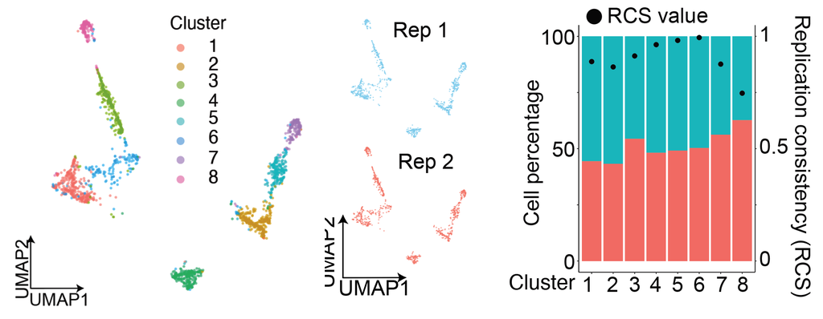

Figure 1: Example UMAP projection of nuclei colored by cluster identity and library, with replicate consistency evaluated using the replicate consistency score (RCS)

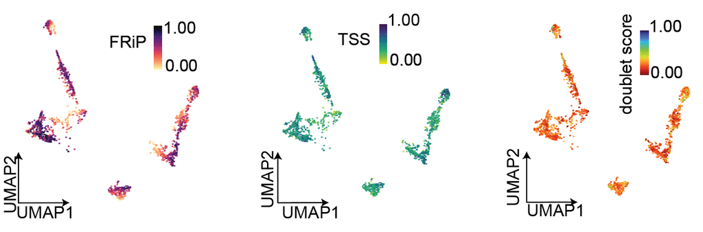

Figure 2: example of UMAP visualization of nuclei, color-coded based on the FRIP, TSS, doublet score per cell

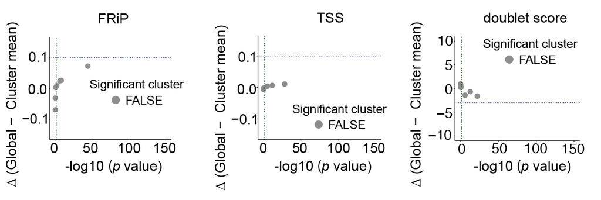

Figure 3: example of Post-clustering quality assessment based on FRiP, TSS, doublet score distribution.

### Option 2: Clustering with a single replicate

If users have only one replicate, they should set -harmony no to prevent errors.

**Running**:

```bash
mkdir input_obj_dir
cp /Path/to/*filtered.soc.qs2 input_obj_dir

python Socrates2/utils/clustering.py
-script_dir Socrates2/utils/input_other_required_scripts_dir
-o output_dir
-ipt_obj_dir input_obj_dir
-harmony no
```

### Option 3: Only perform clustering and change resolution

If users wish to adjust the clustering resolution without re-running the entire process, they can set `-only_cluster yes` and specify an exact value for `-res` to control the clustering resolution.

```bash
python Socrates2/utils/clustering.py
-script_dir Socrates2/utils/input_other_required_scripts_dir
-o output_dir
-ipt_obj_dir input_obj_dir
-only_cluster yes
-res 1
```

### Option 4: Remove low-quality clusters and re-cluster

If some clusters are of low quality — for example, a cluster in which all cells come from a single sample/library — users can remove these clusters and re-cluster the remaining cells. The cluster labels are read from the `*.atac.soc.qs2` object produced by a previous run, so please run the clustering once WITHOUT `-remove_clusters` first, using the same `-o`, `-prefix` and parameters. Then determine the cluster IDs to remove, from the UMAP plots or from the cluster-by-library composition, and re-run with `-remove_clusters`.

```bash
python Socrates2/utils/clustering.py
-script_dir Socrates2/utils/input_other_required_scripts_dir
-o output_dir
-ipt_obj_dir input_obj_dir
-remove_clusters "5"
```

Multiple clusters can be removed at once by providing comma-separated numbers, e.g. `-remove_clusters "1,2"`.

Note that the cluster IDs are assigned by Louvain clustering and can differ between runs, because the dimensional reduction steps are stochastic. Please determine the clusters to remove and then re-run immediately with the same parameters. This option removes the specified cells from the merged object and re-runs the pipeline from the TF-IDF step, which is equivalent to the manual procedure of editing the merged object and re-running the clustering. It cannot be combined with `-only_cluster yes`.

In addition to the regular outputs, the following files are generated (the suffix `rmC5` corresponds to `-remove_clusters "5"`):

1. **output.atac.soc.refsnapshot.qs2** — a snapshot of the cluster labels used as the reference. Repeated removals always refer to this snapshot, so that the cluster numbering stays consistent.
2. **opt_*_rmC5_removed_cells.txt** — details of the cells that were removed.
3. **opt_*_rmC5_removed_cluster_library_composition.txt** — the library composition of the removed cells.

To revert the removal, simply delete the files carrying the `_rmC5` suffix and re-run without `-remove_clusters`; the original intermediate objects are never overwritten. To re-define the baseline (for example after changing parameters), delete `output.atac.soc.refsnapshot.qs2` so that a new snapshot is created on the next run.